# Survey Response Rate and Drop-off Analysis

Zexin Xia

6/23/2017

## Introduction

In this project, we want to explore the trends in the number of responses we had been getting across the following four surveys:

- San Jose Digital Device (SJDD)
- Sirum
- ECN (El Camino Nudge)
- EITC (Earned Income Taxed Credit)

Moreover, we particularly want to investigate whether variables like survey length and status of survey process(in-person vs not in-person) have an effect on survey completion rate, and therefore helping us to improve completion rate in future surveys.

```r
# Load packages.
library(dplyr)
library(ggplot2)
library(gridExtra)
library(data.table)
library(knitr)
```

```r
# Define colors for visualization
ciBlue <- "#11A7A5"
ciOrange <- "#F7931E"
```

```r
##############
# SJDD Panel #
##############

# Import the sjdd dataset.
sjdd <- read.csv("SJC_DDsurvey.csv")

# Substitute "" and NULL entries in the dataset with "NA"
sjdd[sjdd==""] <- NA
sjdd[sjdd=="NULL"] <- NA
```

```r
##################################################
# Respondents with no home internet subscription #
##################################################

# Import the sjdd_nhi dataset.
sjdd_nhi <- read.csv("Cleaned_Nointernet.csv")

# Substitute "" and NULL entries in the dataset with "NA".
sjdd_nhi[sjdd_nhi==""] <- NA
sjdd_nhi[sjdd_nhi=="NULL"] <- NA
```

```r
# Update columns in sjdd with the same columns present in sjdd_nhi.
cols <- setdiff(colnames(sjdd_nhi), "phone_number")
setDT(sjdd)[setDT(sjdd_nhi), (cols) := mget(paste0('i.', cols)), on = "phone_number"]
```

```r
####################################
# Respondents from Recruiters (RR) #
####################################

# Import the Recruited dataset.
Recruited <- read.csv("Recruited.csv")

# Convert dataframe to datatable.
sjdd_dt <- data.table(sjdd)
Recruited_dt <- data.table(Recruited)

# Check to see which respondents in Recruited are also present in sjddand store the result
# in sjdd_recruited.
sjdd_recruited <- sjdd[which(sjdd$phone_number %in% Recruited$phone_number)]
#sjdd_recruited <- sjdd[phone_number %in% Recruited$phone_number,phone_number]
```

```r
####################
# RR with Internet #
####################

# Subset sjdd_recruited to get a dataframe containing columns corresponding to respondents
# with internet.
sjdd_YesInt_df <- select(sjdd_recruited,
                       one_of(c("phone_number","lang_cat","num_child_txt","homeInternet_cat",
                                "child_device_most_used_cat","child_device_2nd_used_cat",
                                "child_homework_device_cat","child_device_work_cat",
                                "child_comm_ppl_cat","child_2nd_comm_ppl_cat",
                                "con_big_child_cat","con_2nd_big_child_cat",
                                "child_internet_access_home_cat","pars_inter_ppl_cat",
                                "pars_2nd_inter_ppl_cat","pars_access_internet_home_cat",
                                "pars_internet_work_cat","why_mobile_cat",
                                "zipcode_txt","income_cat","affordable_housing_cat",
                                "ppl_house_txt","gender_cat","race_cat","birth_year_txt",
                                "future_survey_cat")))

# Subset sjdd_YesInt_df to get a datatable containing rows corresponding to
# respondents with internet.
sjdd_Y_df <- data.table(subset(sjdd_YesInt_df, sjdd_YesInt_df$homeInternet_cat == "Y"))
```

```r
##########################################################
# Number of questions completed vs Number of Respondents #
##########################################################

# Return 1 for all non-NA values in each column and 0 otherwise, then store the result
# in sjdd_Y_non_df grouped by phone_number.
sjdd_Y_non_na <- sjdd_Y_df %>%
  group_by(phone_number) %>%
  summarise_each(funs(sum(!is.na(.))))

# Converting sjdd_Y_non_na to datatable.
sjdd_Y_non_na_dt <- data.table(sjdd_Y_non_na)

# Sum the number of 1's in each row (excluding the key column) and store the result
# in Y_response_count, then add a new column called "Phone" to the datatable using the
# phone_number column from sjdd-Y_non_na_dt.
Y_response_count <- data.table(rowSums(sjdd_Y_non_na_dt[,-1])) %>%
  mutate(Phone = sjdd_Y_non_na_dt[,phone_number])

# Converting to datatable.
Y_response_count <- data.table(Y_response_count)

# Creating storage dataframe.
totalQ <- max(Y_response_count$V1)
responseCountByQ <- data.table(q = 1:totalQ, numResponses = rep(0,totalQ))

# Loop over the storage dataframe.
for(i in 1:totalQ){
  responseCountByQ[q==i, numResponses:= Y_response_count[V1>=i, .N]]
}

# Plot Number of questions responded vs Number of Respondents using geom_line.
sjdd_g1 <- ggplot(data = responseCountByQ, aes(x = q, y = numResponses)) +
  geom_line(color = ciBlue) +
  geom_point()+
  theme_bw() +
  scale_x_continuous(breaks = seq(1,24,by = 2), limits = c(1,24)) +
  scale_y_continuous(breaks = seq(350,500,by = 10), limits = c(350,500)) +
  ggtitle("Drop-off Analysis for SJDD Survey \n(In-person Respondents with Internet)") +
  xlab("Number of Questions Responded") +
  ylab("Number of Respondents") +
  theme(plot.title = element_text(family = "Trebuchet MS",
                                  color = ciOrange,
                                  face = "bold",
                                  size = 10,
                                  hjust = 0.5)) +
  annotate("rect", xmin=22, xmax=24, ymin=350, ymax=500, alpha=.1, fill="green") +
  annotate("rect", xmin=1, xmax=21, ymin=350, ymax=500, alpha=.1, fill="yellow")
```

```r
# Add a column for the response rate of each survey question to responseCountByQ.
sjdd_RRate_1 <- responseCountByQ %>%
  mutate(SJDD_Rate = numResponses/484)
```

```r
############################################
# Question Number vs Number of Respondents #
############################################

# Return 1 for all non-NA values in each column and 0 otherwise, then store the result
# in sjdd_N_order_non_na grouped by phone_number.
sjdd_Y_order_non_na <- sjdd_Y_df %>%
  group_by(phone_number) %>%
  summarise_each(funs(sum(!is.na(.))))

# Sum the number of 1's in each column (excluding the key column) and store the result
# in sirum_order_response_count, then add a new column called "Quesiton" to the datatable.
sjdd_Y_order_response_count <- data.table(colSums(sjdd_Y_order_non_na[,-1])) %>%
  mutate(Question = seq(from=1, to=25, by=1))

# Plot Question Number against Number of Respondents using geom_line.
sjdd_g2 <- ggplot(data = sjdd_Y_order_response_count, aes(x = Question, y = V1)) +
  geom_line(color = ciBlue) +
  theme_bw()+
  scale_x_continuous(breaks = seq(1,25,by = 2), limits = c(1,25)) +
  scale_y_continuous(breaks = seq(0,500,by = 50), limits = c(0,500)) +
  ggtitle(paste("Number of Response on each Survey Question \n(In-person Respondents with Internet)")) +
  xlab("Question Number") +
  ylab("Number of Response") +
  theme(plot.title = element_text(family = "Trebuchet MS",
                                  color = ciOrange,
                                  face = "bold",
                                  size = 10,
                                  hjust = 0.5)) +
  annotate("rect", xmin=15, xmax=18, ymin=0, ymax=500, alpha=.1, fill="red") +
  annotate("segment", x = 11, xend = 16, y = 130, yend = 162, colour="black", size=0.3, arrow=arrow()) +
  annotate("segment", x = 22, xend = 17, y = 250, yend = 309, colour="black", size=0.3, arrow=arrow()) +
  annotate("text", x = 9, y = 100, label= "162 selected \nother devices") +
  annotate("text", x = 22, y = 225, label= "309 selected \nMobile") +
  annotate("rect", xmin=6, xmax=10, ymin=375, ymax=500, alpha=.1, fill="blue") +
  annotate("segment", x = 8, xend = 8, y = 300, yend = 370, colour="black", size=0.3, arrow=arrow()) +
  annotate("text", x = 8, y = 275, label= "388 did not \nselect None")
```

For each pair of plots below, the horizontal axis of the line graph on the left indicates the total numnber of questions answered by respondents, whereas the horizontal axis of the line graph on the right indicates the Question Number in the survey.

There are four groups of respondents in the SJDD survey:

1). Have Internet and answered the questions in-person.

2). Have Internet and **did not** answer the quesitons in-person.

3). Have **no** Internet and answered the questions in-perosn.

4). Have **no** Internet and **did not** answer the quesitons in-person.

### SJDD Survey (In-person and with Internet)

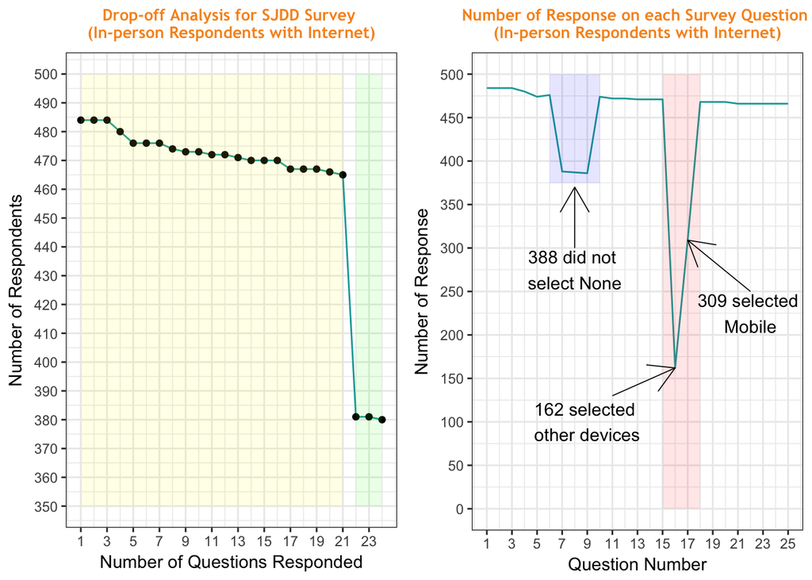

```r
#Arrange the two plots side by side.
grid.arrange(sjdd_g1,sjdd_g2, ncol = 2)
```

There are 484 respondents in this group, and all of them have internet access and answered the survey in-person. The total number of quesitons in the survey is 24. The graph on the left shows that the number of respondents (y-axis) for the number of questions responded (x-axis) follows a gradual decreasing trend for the first 21 questions (shaded in yellow). The points in green region represents the number of respondents completed 22 questions and more, which there are about 380 of them. The decrease in number of respondents can be explained by the graph on the right, which allows us to see how many responses we got for each question in the survey. The dip (shaded in red) at question #16 is due to respondents’ answers to question #15: Question #15 asked respondents “How do you get your Internet access for your device at home?”, and if they selected A, which is “Mobile phone plan with data”, then the system would skip question #16 for these respondents and move on directly to question #17.In other words, question #15 splits the flow into two paths based on whether they selected Mobile phone data as their way to access internet, one of which leads to question #16 (162 respondents) and the other responded to question #17 (309 respondents). After question #17, these two paths were merged back into a single path in the flow starting at quesiton #18. Similarily, the other decrease in the number of respondenses (shaded in blue) on questions 7,8,and 9 is due to respondents’ answers to question #6: “What device do your children do their homework on?”. If the respondents selected “G”, which is “None”, then the system would skip the following three questions (7,8 and 9) and move on directly to question #10. Therefore, the difference in number of respondents between the yellow region and the green region in the first graph is a result of missing responses on quesitons in the blue and red regions in the second graph. Overall it appears that almost all respondents in this group answered every question they saw in the survey.

```r
#######################
# RR with no Internet #
#######################

# Subset sjdd_recruited to get a dataframe containing columns corresponding to respondents
# with no internet.
sjdd_NoInt_df <- select(sjdd_recruited,
                     one_of(c("phone_number","lang_cat","num_child_txt","homeInternet_cat",
                              "benefit_internet_cat","internet_bar_top_cat",
                              "internet_bar_2nd_top_cat","nhi_pars_inter_ppl_cat",
                              "nhi_pars_2nd_inter_ppl_cat","internet_away_home_cat",
                              "nhi_child_comm_ppl_cat","nhi_child_2nd_comm_ppl_cat",
                              "child_where_access_cat","nhi_con_big_child_cat",
                              "nhi_con_2nd_big_child_cat","trust_signup_cat",
                              "trust_signup_2nd_cat","most_afford_internet_cat",
                              "bar_signup_top_cat","bar_signup_2nd_cat",
                              "nhi_zipcode_txt","nhi_income_cat","nhi_affordable_housing_cat",
                              "nhi_ppl_house_txt","nhi_gender_cat","nhi_race_cat",
                              "nhi_birth_year_txt","nhi_future_survey_cat")))

# Subset sjdd_NoInt_df to get a datatable containing rows corresponding to
# respondents with internet.
sjdd_N_df <- data.table(subset(sjdd_NoInt_df, sjdd_NoInt_df$homeInternet_cat == "N"))
```

```r
##########################################################
# Number of questions completed vs Number of Respondents #
##########################################################

# Return 1 for all non-NA values in each column and 0 otherwise, then store the result
# in sjdd_N_non_df grouped by phone_number.
sjdd_N_non_na <- sjdd_N_df %>%
  group_by(phone_number) %>%
  summarise_each(funs(sum(!is.na(.))))

# Converting sjdd_Y_non_na to datatable.
sjdd_N_non_na_dt <- data.table(sjdd_N_non_na)

# Sum the number of 1's in each row (excluding the key column) and store the result
# in N_response_count, then add a new column called "Phone" to the datatable using the
# phone_number column from sjdd_N_non_na_dt.
N_response_count <- data.table(rowSums(sjdd_N_non_na_dt[,-1])) %>%
  mutate(Phone = sjdd_N_non_na_dt[,phone_number])

# Converting to datatable.
N_response_count <- data.table(N_response_count)

# Creating storage dataframe.
totalQ <- max(N_response_count$V1)
responseCountByQ <- data.table(q = 1:totalQ, numResponses = rep(0,totalQ))

# Loop over the storage dataframe.
for(i in 1:totalQ){
  responseCountByQ[q==i, numResponses:= N_response_count[V1>=i, .N]]
}

# Plot Number of questions responded vs Number of Respondents using geom_line.
sjdd_g3 <- ggplot(data = responseCountByQ, aes(x = q, y = numResponses)) +
  geom_line(color = ciBlue) +
  geom_point()+
  theme_bw() +
  scale_x_continuous(breaks = seq(1,27,by = 2), limits = c(1,27)) +
  scale_y_continuous(breaks = seq(115,125,by = 1), limits = c(115,125)) +
  ggtitle("Drop-off Analysis for SJDD Survey \n(In-Person Respondents with no Internet)") +
  xlab("Number of Questions Responded") +
  ylab("Number of Respondents") +
  theme(plot.title = element_text(family = "Trebuchet MS",
                                  color = ciOrange,
                                  face = "bold",
                                  size = 10,
                                  hjust = 0.5))
```

```r
# Add a column for the response rate of each survey question to responseCountByQ.
sjdd_RRate_2 <- responseCountByQ %>%
  mutate(SJDD_Rate = numResponses/124)
```

```r
############################################
# Question Number vs Number of Respondents #
############################################

# Return 1 for all non-NA values in each column and 0 otherwise, then store the result
# in sjdd_N_order_non_na grouped by phone_number.
sjdd_N_order_non_na <- sjdd_N_df %>%
  group_by(phone_number) %>%
  summarise_each(funs(sum(!is.na(.))))

# Sum the number of 1's in each column (excluding the key column) and store the result
# in sirum_order_response_count, then add a new column called "Quesiton" to the datatable.
sjdd_N_order_response_count <- data.table(colSums(sjdd_N_order_non_na[,-1])) %>%
  mutate(Question = seq(from=1, to=27, by=1))

# Plot Question Number against Number of Respondents using geom_line.
sjdd_g4 <- ggplot(data = sjdd_N_order_response_count, aes(x = Question, y = V1)) +
  geom_line(color = ciBlue) +
  theme_bw()+
  scale_x_continuous(breaks = seq(1,27,by = 2), limits = c(1,27)) +
  scale_y_continuous(breaks = seq(115,125,by = 1), limits = c(115,125)) +
  ggtitle(paste("Number of Response on each Survey Question \n(In-Person Respondents with no Internet)")) +
  xlab("Question Number") +
  ylab("Number of Response") +
  theme(plot.title = element_text(family = "Trebuchet MS",
                                  color = ciOrange,
                                  face = "bold",
                                  size = 10,
                                  hjust = 0.5))
```

### SJDD Survey (In-person and with NO Internet)

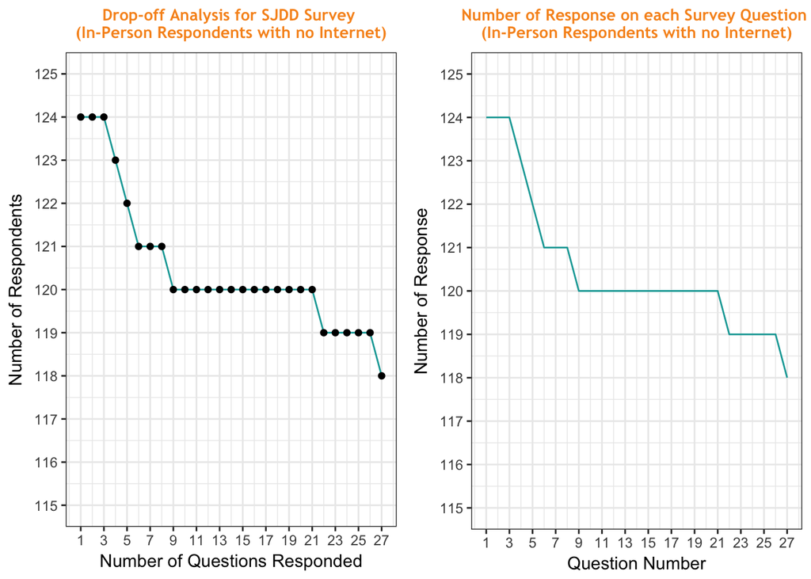

```r
#Arrange the two plots side by side.
grid.arrange(sjdd_g3,sjdd_g4, ncol = 2)
```

```r
############################################
# Respondents NOT from Recruiters (non-RR) #
############################################

# Check to see which respondents in sjdd are NOT present in Recruited and store the result
# in sjdd_non_recruited.
sjdd_non_recruited <- sjdd[which(!sjdd$phone_number %in% Recruited$phone_number)]
```

```r
########################
# non-RR with Internet #
########################

# Subset sjdd_non_recruited to get a dataframe containing columns corresponding to respondents
# with internet.
sjdd_YesInt_non_df <- select(sjdd_non_recruited,
                       one_of(c("phone_number","lang_cat","num_child_txt","homeInternet_cat",
                                "child_device_most_used_cat","child_device_2nd_used_cat",
                                "child_homework_device_cat","child_device_work_cat",
                                "child_comm_ppl_cat","child_2nd_comm_ppl_cat",
                                "con_big_child_cat","con_2nd_big_child_cat",
                                "child_internet_access_home_cat","pars_inter_ppl_cat",
                                "pars_2nd_inter_ppl_cat","pars_access_internet_home_cat",
                                "pars_internet_work_cat","why_mobile_cat",
                                "zipcode_txt","income_cat","affordable_housing_cat",
                                "ppl_house_txt","gender_cat","race_cat","birth_year_txt",
                                "future_survey_cat")))

# Subset sjdd_YesInt_non_df to get a datatable containing rows corresponding to
# respondents with internet.
sjdd_Y_non_df <- data.table(subset(sjdd_YesInt_non_df, sjdd_YesInt_non_df$homeInternet_cat == "Y"))
```

```r
##########################################################
# Number of questions completed vs Number of Respondents #
##########################################################

# Return 1 for all non-NA values in each column and 0 otherwise, then store the result
# in sjdd_Y_nonRR_df grouped by phone_number.
sjdd_Y_nonRR_na <- sjdd_Y_non_df %>%
  group_by(phone_number) %>%
  summarise_each(funs(sum(!is.na(.))))

# Converting sjdd_Y_nonRR_na to datatable.
sjdd_Y_nonRR_na_dt <- data.table(sjdd_Y_nonRR_na)

# Sum the number of 1's in each row (excluding the key column) and store the result
# in Y_response_count, then add a new column called "Phone" to the datatable using the
# phone_number column from sjdd-Y_non_na_dt.
Y_responseRR_count <- data.table(rowSums(sjdd_Y_nonRR_na_dt[,-1])) %>%
  mutate(Phone = sjdd_Y_nonRR_na_dt[,phone_number])

# Converting to datatable.
Y_responseRR_count <- data.table(Y_responseRR_count)

# Creating storage dataframe.
totalQ <- max(Y_responseRR_count$V1)
responseCountByQ <- data.table(q = 1:totalQ, numResponses = rep(0,totalQ))

# Loop over the storage dataframe.
for(i in 1:totalQ){
  responseCountByQ[q==i, numResponses:= Y_responseRR_count[V1>=i, .N]]
}

# Plot Number of questions responded vs Number of Respondents using geom_line.
sjdd_g5 <- ggplot(data = responseCountByQ, aes(x = q, y = numResponses)) +
  geom_line(color = ciBlue) +
  geom_point()+
  theme_bw() +
  scale_x_continuous(breaks = seq(1,24,by = 2), limits = c(1,24)) +
  scale_y_continuous(breaks = seq(235,270,by = 5), limits = c(235,270)) +
  ggtitle("Drop-off Analysis for SJDD Survey \n(Respondents not In-person with Internet)") +
  xlab("Number of Questions Responded") +
  ylab("Number of Respondents") +
  theme(plot.title = element_text(family = "Trebuchet MS",
                                  color = ciOrange,
                                  face = "bold",
                                  size = 10,
                                  hjust = 0.5)) +
  annotate("rect", xmin=22, xmax=24, ymin=235, ymax=270, alpha=.1, fill="green") +
  annotate("rect", xmin=1, xmax=21, ymin=235, ymax=270, alpha=.1, fill="yellow")
```

```r
# Add a column for the response rate of each survey question to responseCountByQ.
sjdd_RRate_3 <- responseCountByQ %>%
  mutate(SJDD_Rate = numResponses/266)
```

```r
############################################
# Question Number vs Number of Respondents #
############################################

# Return 1 for all non-NA values in each column and 0 otherwise, then store the result
# in sjdd_N_nonRR_order_non_na grouped by phone_number.
sjdd_Y_nonRR_order_non_na <- sjdd_Y_non_df %>%
  group_by(phone_number) %>%
  summarise_each(funs(sum(!is.na(.))))

# Sum the number of 1's in each column (excluding the key column) and store the result
# in sirum_order_response_count, then add a new column called "Quesiton" to the datatable.
sjdd_Y_nonRR_order_response_count <- data.table(colSums(sjdd_Y_nonRR_order_non_na[,-1])) %>%
  mutate(Question = seq(from=1, to=25, by=1))

# Plot Question Number against Number of Respondents using geom_line.
sjdd_g6 <- ggplot(data = sjdd_Y_nonRR_order_response_count, aes(x = Question, y = V1)) +
  geom_line(color = ciBlue) +
  theme_bw()+
  scale_x_continuous(breaks = seq(1,25,by = 2), limits = c(1,25)) +
  scale_y_continuous(breaks = seq(0,300,by = 50), limits = c(0,300)) +
  ggtitle(paste("Number of Response on each Survey Question \n(Respondents not In-Person with Internet)")) +
  xlab("Question Number") +
  ylab("Number of Response") +
  theme(plot.title = element_text(family = "Trebuchet MS",
                                  color = ciOrange,
                                  face = "bold",
                                  size = 10,
                                  hjust = 0.5)) +
  annotate("rect", xmin=15, xmax=18, ymin=0, ymax=300, alpha=.1, fill="red") +
  annotate("segment", x = 21, xend = 17, y = 50, yend = 86, colour="black", size=0.3, arrow=arrow()) +
  annotate("segment", x = 11, xend = 16, y = 150, yend = 178, colour="black", size=0.3, arrow=arrow()) +
  annotate("text", x = 9, y = 125, label= "178 selected \nother devices") +
  annotate("text", x = 22, y = 25, label= "86 selected \nMobile") +
  annotate("rect", xmin=6, xmax=10, ymin=225, ymax=300, alpha=.1, fill="blue") +
  annotate("segment", x = 8, xend = 8, y = 200, yend = 245, colour="black", size=0.3, arrow=arrow()) +
  annotate("text", x = 8, y = 180, label= " 245 did not \nselect None")
```

### SJDD Survey (not In-person and with Internet)

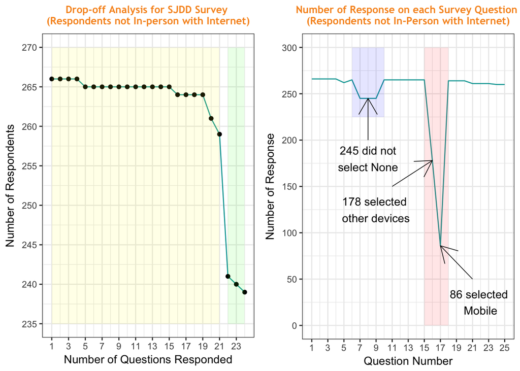

```r
#Arrange the two plots side by side.
grid.arrange(sjdd_g5,sjdd_g6, ncol = 2)
```

There are 266 respondents in this group, and all of them have internet access and DID NOT answer the survey in-person. The total number of quesitons in the survey is 24. This pair of line graphs looks very similar to that of In-person respondents with Internet; the main difference here is that more respondents answered quesiton #16 than #17. The difference in number of respondents between the yellow region and the green region in the first graph is a result of missing responses on quesitons in the blue and red regions in the second graph. Overall it appears that almost all respondents in this group answered every question they saw in the survey.

```r
###########################
# non-RR with no Internet #
###########################

# Subset sjdd_non_recruited to get a dataframe containing columns corresponding to respondents
# with no internet.
sjdd_NoInt_non_df <- select(sjdd_non_recruited,
                     one_of(c("phone_number","lang_cat","num_child_txt","homeInternet_cat",
                              "benefit_internet_cat","internet_bar_top_cat",
                              "internet_bar_2nd_top_cat","nhi_pars_inter_ppl_cat",
                              "nhi_pars_2nd_inter_ppl_cat","internet_away_home_cat",
                              "nhi_child_comm_ppl_cat","nhi_child_2nd_comm_ppl_cat",
                              "child_where_access_cat","nhi_con_big_child_cat",
                              "nhi_con_2nd_big_child_cat","trust_signup_cat",
                              "trust_signup_2nd_cat","most_afford_internet_cat",
                              "bar_signup_top_cat","bar_signup_2nd_cat",
                              "nhi_zipcode_txt","nhi_income_cat","nhi_affordable_housing_cat",
                              "nhi_ppl_house_txt","nhi_gender_cat","nhi_race_cat",
                              "nhi_birth_year_txt","nhi_future_survey_cat")))

# Subset sjdd_NoInt_non_df to get a datatable containing rows corresponding to
# respondents with no internet.
sjdd_N_non_df <- data.table(subset(sjdd_NoInt_non_df, sjdd_NoInt_non_df$homeInternet_cat == "N"))
```

```r
##########################################################
# Number of questions completed vs Number of Respondents #
##########################################################

# Return 1 for all non-NA values in each column and 0 otherwise, then store the result
# in sjdd_Y_nonRR_df grouped by phone_number.
sjdd_N_nonRR_na <- sjdd_N_non_df %>%
  group_by(phone_number) %>%
  summarise_each(funs(sum(!is.na(.))))

# Converting sjdd_N_nonRR_na to datatable.
sjdd_N_nonRR_na_dt <- data.table(sjdd_N_nonRR_na)

# Sum the number of 1's in each column (excluding the key column) and store the result
# in N_response_count, then add a new column called "Phone" to the datatable using the
# phone_number column from sjdd_N_non_na_dt.
N_responseRR_count <- data.table(rowSums(sjdd_N_nonRR_na_dt[,-1])) %>%
  mutate(Phone = sjdd_N_nonRR_na_dt[,phone_number])

# Converting to datatable.
N_responseRR_count <- data.table(N_responseRR_count)

# Creating storage dataframe.
totalQ <- max(N_responseRR_count$V1)
responseCountByQ <- data.table(q = 1:totalQ, numResponses = rep(0,totalQ))

# Loop over the storage dataframe.
for(i in 1:totalQ){
  responseCountByQ[q==i, numResponses:= N_responseRR_count[V1>=i, .N]]
}

# Plot Number of questions responded vs Number of Respondents using geom_line.
sjdd_g7 <- ggplot(data = responseCountByQ, aes(x = q, y = numResponses)) +
  geom_line(color = ciBlue) +
  geom_point()+
  theme_bw() +
  scale_x_continuous(breaks = seq(1,27,by = 2), limits = c(1,27)) +
  scale_y_continuous(breaks = seq(0,9,by = 1), limits = c(0,9)) +
  ggtitle("Drop-off Analysis for SJDD Survey \n(non-Recruiter Respondents with no Internet)") +
  xlab("Number of Questions Responded") +
  ylab("Number of Respondents") +
  theme(plot.title = element_text(family = "Trebuchet MS",
                                  color = ciOrange,
                                  face = "bold",
                                  size = 10,
                                  hjust = 0.5))
```

```r
# Add a column for the response rate of each survey question to responseCountByQ.
sjdd_RRate_4 <- responseCountByQ %>%
  mutate(SJDD_Rate = numResponses/9)
```

```r
############################################
# Question Number vs Number of Respondents #
############################################

# Return 1 for all non-NA values in each column and 0 otherwise, then store the result
# in sjdd_N_nonRR_order_non_na grouped by phone_number.
sjdd_N_nonRR_order_non_na <- sjdd_N_non_df %>%
  group_by(phone_number) %>%
  summarise_each(funs(sum(!is.na(.))))

# Sum the number of 1's in each column (excluding the key column) and store the result
# in sirum_order_response_count, then add a new column called "Quesiton" to the datatable.
sjdd_N_nonRR_order_response_count <- data.table(colSums(sjdd_N_nonRR_order_non_na[,-1])) %>%
  mutate(Question = seq(from=1, to=27, by=1))

# Plot Question Number against Number of Respondents using geom_line.
sjdd_g8 <- ggplot(data = sjdd_N_nonRR_order_response_count, aes(x = Question, y = V1)) +
  geom_line(color = ciBlue) +
  theme_bw()+
  scale_x_continuous(breaks = seq(1,27,by = 2), limits = c(1,27)) +
  scale_y_continuous(breaks = seq(0,9,by = 1), limits = c(0,9)) +
  ggtitle(paste("Number of Response on each Survey Question \n(non-Recruiter Respondents with no Internet)")) +
  xlab("Question Number") +
  ylab("Number of Response") +
  theme(plot.title = element_text(family = "Trebuchet MS",
                                  color = ciOrange,
                                  face = "bold",
                                  size = 10,
                                  hjust = 0.5))
```

### SJDD Survey (not In-person and with no Internet)

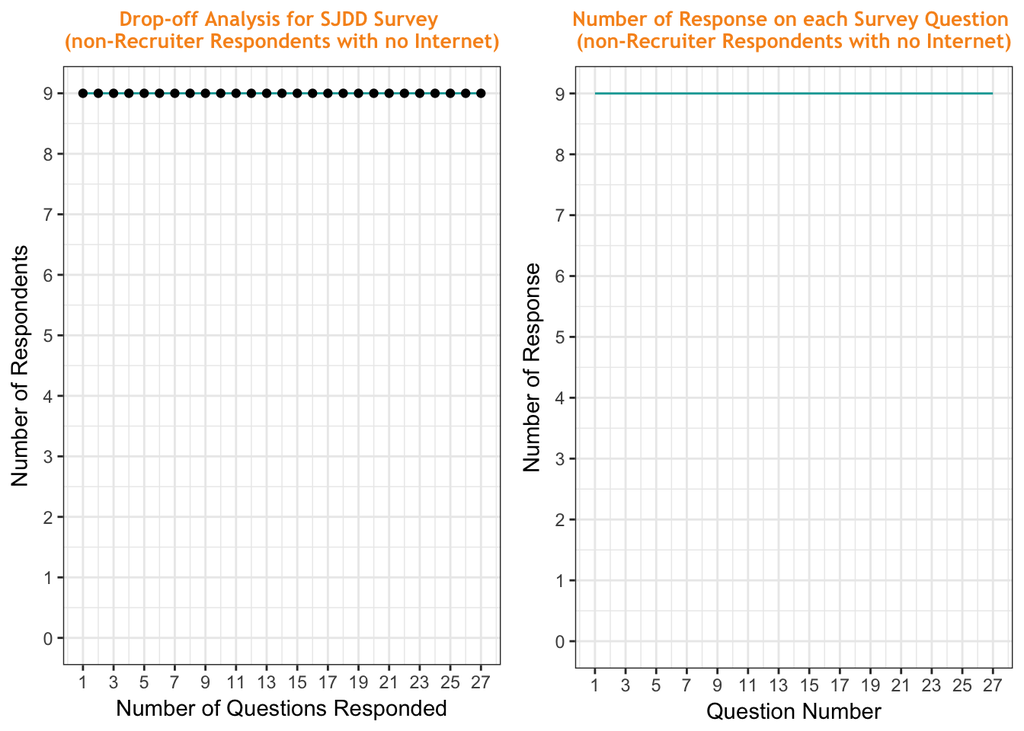

```r
#Arrange the two plots side by side.
grid.arrange(sjdd_g7,sjdd_g8, ncol = 2)
```

```r
###############
# Sirum Panel #
###############

# Import the sirum dataset.
sirum <- read.csv("Sirum.csv")

# Substitute "" and NULL entries in the dataset with "NA"
sirum[sirum==""] <- NA
sirum[sirum=="NULL"] <- NA

# Convert dataframe to datatable for easy processing.
sirum_dt <- data.table(sirum)

# Change variable name "URN" to "phone_number".
setnames(sirum_dt, "URN", "phone_number")

# Remove column "Contact.UUID" and "SentSurvey" from the datatable.
sirum_dt[, c("Contact.UUID","SentSurvey"):= NULL]
```

```r
############################################
# Question Number vs Number of Respondents #
############################################

# Return 1 for all non-NA values in each column and 0 otherwise, then store the result
# in sirum_non_na grouped by phone_number.
sirum_non_na <- sirum_dt %>%
  group_by(phone_number) %>%
  summarise_each(funs(sum(!is.na(.))))

# Converting sirum_non_na to datatable.
sirum_non_na_dt <- data.table(sirum_non_na)

# Sum the number of 1's in each row (excluding the key column) and store the result
# in sirum_response_count, then add a new column called "Quesiton" to the datatable.
sirum_response_count <- data.table(rowSums(sirum_non_na_dt[,-1])) %>%
  mutate(Phone = sirum_non_na_dt[,phone_number])

# Converting to datatable.
sirum_response_count <- data.table(sirum_response_count)

# Creating storage dataframe.
totalQ <- max(sirum_response_count$V1)
responseCountByQ <- data.table(q = 1:totalQ, numResponses = rep(0,totalQ))

# Loop over the storage dataframe.
for(i in 1:totalQ){
  responseCountByQ[q==i, numResponses:= sirum_response_count[V1>=i, .N]]
}

# Plot Number of questions responded vs Number of Respondents using geom_line.
sirum_g1 <- ggplot(data = responseCountByQ, aes(x = q, y = numResponses)) +
  geom_line(color = ciBlue) +
  geom_point()+
  theme_bw() +
  scale_x_continuous(breaks = seq(1,19,by = 2), limits = c(1,19)) +
  scale_y_continuous(breaks = seq(0,200,by = 50), limits = c(0,200)) +
  ggtitle("Drop-off Analysis for Sirum Survey") +
  xlab("Number of Questions Responded") +
  ylab("Number of Respondents") +
  theme(plot.title = element_text(family = "Trebuchet MS",
                                  color = ciOrange,
                                  face = "bold",
                                  size = 12,
                                  hjust = 0.5)) +
  annotate("rect", xmin=1, xmax=14, ymin=0, ymax=200, alpha=.1, fill="yellow") +
  annotate("rect", xmin=15, xmax=19, ymin=0, ymax=200, alpha=.1, fill="green")
```

```r
# Add a column for the response rate of each survey question to responseCountByQ.
sirum_RRate <- responseCountByQ %>%
  mutate(Sirum_Rate = numResponses/199)
```

```r
############################################
# Question Number vs Number of Respondents #
############################################

# Return 1 for all non-NA values in each column and 0 otherwise, then store the result
# in sirum_order_non_na grouped by phone_number.
sirum_order_non_na <- sirum_dt %>%
  group_by(phone_number) %>%
  summarise_each(funs(sum(!is.na(.))))

# Sum the number of 1's in each column (excluding the key column) and store the result
# in sirum_order_response_count, then add a new column called "Quesiton" to the datatable.
sirum_order_response_count <- data.table(colSums(sirum_order_non_na[,-1])) %>%
  mutate(Question = seq(from=1, to=19, by=1))

# Plot Question Number against Number of Respondents using geom_line.
sirum_g2 <- ggplot(data = sirum_order_response_count, aes(x = Question, y = V1)) +
  geom_line(color = ciBlue) +
  theme_bw()+
  scale_x_continuous(breaks = seq(1,19,by = 2), limits = c(1,19)) +
  scale_y_continuous(breaks = seq(0,230,by = 50), limits = c(0,230)) +
  ggtitle(paste("Number of Response on each Survey Question \n(Sirum)")) +
  xlab("Question Number") +
  ylab("Number of Response") +
  theme(plot.title = element_text(family = "Trebuchet MS",
                                  color = ciOrange,
                                  face = "bold",
                                  size = 10,
                                  hjust = 0.5)) +
  annotate("rect", xmin=9, xmax=10, ymin=0, ymax=230, alpha=.1, fill="orange") +
  annotate("rect", xmin=11.5, xmax=12.5, ymin=0, ymax=230, alpha=.1, fill="orange") +
  annotate("rect", xmin=13.5, xmax=15.5, ymin=0, ymax=230, alpha=.1, fill="orange")
```

### Sirum Survey

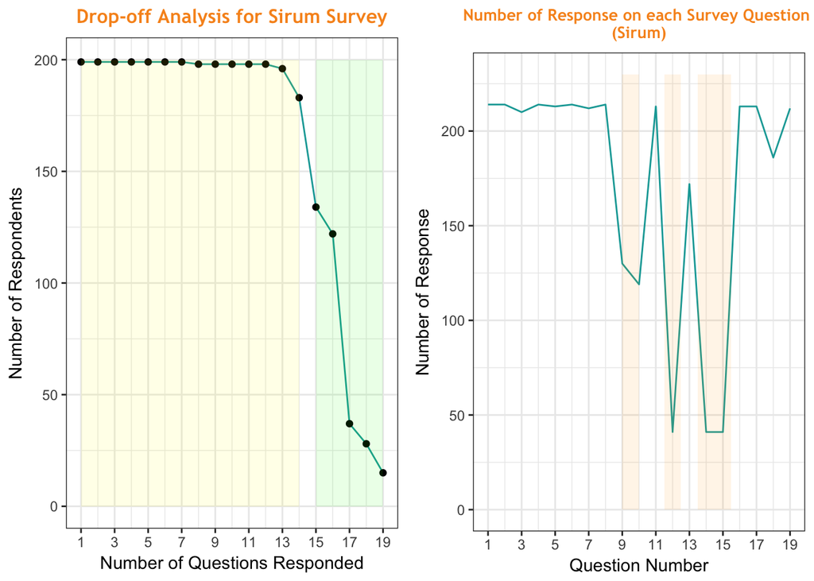

```r
#Arrange the two plots side by side.
grid.arrange(sirum_g1, sirum_g2, ncol = 2)
```

There are 214 respondents in this survey, and all of the respondents did not take the survey in-person. There is a total of 19 quesitons in the survey. As shown in the line graph on the left, the number of respondents starts to drop off after 14 questions were answered. The line graph on the right shows that there are some significant decrease (shaded in orange) in number of response on the following quesitons:

*#9. “In the past year, have you taken less medicine than you should to make our prescrition last longer?”

*#10.“In the past year, have you spent less on other things such as groceries in order to pay your prescription medications?”

*#12.“Better Health Parmacy, run by Santa Clara County, fills prescriptions for free for patients who cannot afford them, no ID required. Would you like more information about this?”

*#14.“How many of your medications have you been able to fill with this pharmacy?”

*#15.“Would you recommend this pharmacy to family or friends in need?”

```r
#############
# ECN Panel #
#############

# Import the ecn dataset.
ecn <- read.csv("Pre-ECN_Flow.csv")

# Substitute "" and NULL entries in the dataset with "NA"
ecn[ecn==""] <- NA
ecn[ecn=="NULL"] <- NA

# Convert dataframe to datatable for easy processing.
ecn_dt <- data.table(ecn)

# Change variable name "URN" to "phone_number".
setnames(ecn_dt, "URN", "phone_number")

# Remove column "Contact.UUID" and "SentSurvey" from the datatable.
ecn_dt[, c("X","X.1","X.2","X.3"):= NULL]
```

```r
############################################
# Question Number vs Number of Respondents #
############################################

# Return 1 for all non-NA values in each column and 0 otherwise, then store the result
# in sirum_non_na grouped by phone_number.
ecn_non_na <- ecn_dt %>%
  group_by(phone_number) %>%
  summarise_each(funs(sum(!is.na(.))))

# Converting sirum_non_na to datatable.
ecn_non_na_dt <- data.table(ecn_non_na)

# Sum the number of 1's in each row (excluding the key column) and store the result
# in ecn_response_count, then add a new column called "Quesiton" to the datatable.
ecn_response_count <- data.table(rowSums(ecn_non_na_dt[,-1])) %>%
  mutate(Phone = ecn_non_na_dt[,phone_number])

# Converting to datatable.
ecn_response_count <- data.table(ecn_response_count)

# Creating storage dataframe.
totalQ <- max(ecn_response_count$V1)
responseCountByQ <- data.table(q = 1:totalQ, numResponses = rep(0,totalQ))

# Loop over the storage dataframe.
for(i in 1:totalQ){
  responseCountByQ[q==i, numResponses:= ecn_response_count[V1>=i, .N]]
}

# Plot Number of questions responded vs Number of Respondents using geom_line.
ecn_g1 <- ggplot(data = responseCountByQ, aes(x = q, y = numResponses)) +
  geom_line(color = ciBlue) +
  geom_point()+
  theme_bw() +
  scale_x_continuous(breaks = seq(1,32,by = 2), limits = c(1,32)) +
  scale_y_continuous(breaks = seq(0,400,by = 50), limits = c(0,400)) +
  ggtitle("Drop-off Analysis for ECN Survey") +
  xlab("Number of Questions Responded") +
  ylab("Number of Respondents") +
  theme(plot.title = element_text(family = "Trebuchet MS",
                                  color = ciOrange,
                                  face = "bold",
                                  size = 12,
                                  hjust = 0.5)) +
  annotate("rect", xmin=1, xmax=26, ymin=0, ymax=400, alpha=.1, fill="yellow") +
  annotate("rect", xmin=27, xmax=32, ymin=0, ymax=400, alpha=.1, fill="green")
```

```r
# Add a column for the response rate of each survey question to responseCountByQ.
ecn_RRate <- responseCountByQ %>%
  mutate(ECN_Rate = numResponses/390)
```

```r
############################################
# Question Number vs Number of Respondents #
############################################

# Return 1 for all non-NA values in each column and 0 otherwise, then store the result
# in ecn_non_na grouped by phone_number.
ecn_order_non_na <- ecn_dt %>%
  group_by(phone_number) %>%
  summarise_each(funs(sum(!is.na(.))))

# Sum the number of 1's in each column (excluding the key column) and store the result
# in ecn_order_response_count, then add a new column called "Quesiton" to the datatable.
ecn_order_response_count <- data.table(colSums(ecn_order_non_na[,-1])) %>%
  mutate(Question = seq(from=1, to=36, by=1))

# Plot Question Number against Number of Respondents using geom_line.
ecn_g2 <- ggplot(data = ecn_order_response_count, aes(x = Question, y = V1)) +
  geom_line(color = ciBlue) +
  theme_bw()+
  scale_x_continuous(breaks = seq(1,36,by = 2), limits = c(1,36)) +
  scale_y_continuous(breaks = seq(0,400,by = 50), limits = c(0,400)) +
  ggtitle(paste("Number of Response on each Survey Question \n(ECN)")) +
  xlab("Question Number") +
  ylab("Number of Response") +
  theme(plot.title = element_text(family = "Trebuchet MS",
                                  color = ciOrange,
                                  face = "bold",
                                  size = 10,
                                  hjust = 0.5)) +
  annotate("rect", xmin=17.5, xmax=23.5, ymin=0, ymax=400, alpha=.1, fill="red") +
  annotate("rect", xmin=27.5, xmax=33.5, ymin=0, ymax=400, alpha=.1, fill="blue")
```

### El Camino Nudge Survey

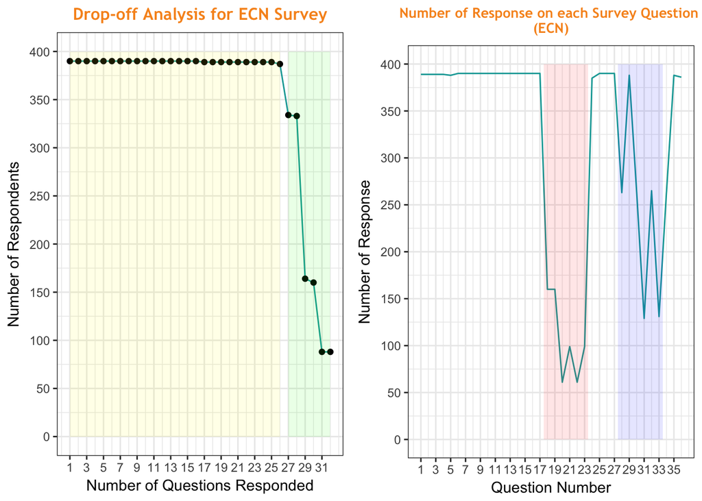

```r
#Arrange the two plots side by side.
grid.arrange(ecn_g1, ecn_g2, ncol = 2)
```

There are 390 respondents in this survey, and all of them did not take the survey in-person. The total number of quesitons in this survey is 36. As shown in the line graph on the left, the number of respondents starts to drop off after 26 questions were answered. Again, the line graph on the right shows that there are some significant decrease in number of response on some quesitons. The quesitons in the red region correspond to the ones related to kids, therefore if the respondents do not have kids then these questions do not apply to them and would be skipped. Similarily, the quesitions in the blue region correspond to the ones related to education, therefore if the respondents do not have any educational backgrounds then the these questions would be skipped as well. Notice that there are almost 390 responses on quesiton 35, this indicates that almost everyone answered every question they saw in the survey.

```r
##############
# EITC Panel #
##############

# Import the eitc dataset.
eitc <- read.csv("EITC_Flow.csv")

# Substitute "" and NULL entries in the dataset with "NA"
eitc[eitc==""] <- NA
eitc[eitc=="NULL"] <- NA

# Convert dataframe to datatable for easy processing.
eitc_dt <- data.table(eitc)

# Change variable name "URN" to "phone_number".
setnames(eitc_dt, "URN", "phone_number")
```

```r
############################################
# Question Number vs Number of Respondents #
############################################

# Return 1 for all non-NA values in each column and 0 otherwise, then store the result
# in eitc_non_na grouped by phone_number.
eitc_non_na <- eitc_dt %>%
  group_by(phone_number) %>%
  summarise_each(funs(sum(!is.na(.))))

# Converting eitc_non_na to datatable.
eitc_non_na_dt <- data.table(eitc_non_na)

# Sum the number of 1's in each row (excluding the key column) and store the result
# in eitc_response_count, then add a new column called "Quesiton" to the datatable.
eitc_response_count <- data.table(rowSums(eitc_non_na_dt[,-1])) %>%
  mutate(Phone = eitc_non_na_dt[,phone_number])

# Converting to datatable.
eitc_response_count <- data.table(eitc_response_count)

# Creating storage dataframe.
totalQ <- max(eitc_response_count$V1)
responseCountByQ <- data.table(q = 1:totalQ, numResponses = rep(0,totalQ))

# Loop over the storage dataframe.
for(i in 1:totalQ){
  responseCountByQ[q==i, numResponses:= eitc_response_count[V1>=i, .N]]
}

# Plot Number of questions responded vs Number of Respondents using geom_line.
eitc_g1 <- ggplot(data = responseCountByQ, aes(x = q, y = numResponses)) +
  geom_line(color = ciBlue) +
  geom_point()+
  theme_bw() +
  scale_x_continuous(breaks = seq(1,24,by = 2), limits = c(1,24)) +
  scale_y_continuous(breaks = seq(0,475,by = 50), limits = c(0,475)) +
  ggtitle("Drop-off Analysis for EITC Survey") +
  xlab("Number of Questions Responded") +
  ylab("Number of Respondents") +
  theme(plot.title = element_text(family = "Trebuchet MS",
                                  color = ciOrange,
                                  face = "bold",
                                  size = 10,
                                  hjust = 0.5))
```

```r
# Add a column for the response rate of each survey question to responseCountByQ.
eitc_RRate <- responseCountByQ %>%
  mutate(EITC_Rate = numResponses/458)
```

```r
############################################
# Question Number vs Number of Respondents #
############################################

# Return 1 for all non-NA values in each column and 0 otherwise, then store the result
# in eitc_order_non_na grouped by phone_number.
eitc_order_non_na <- eitc_dt %>%
  group_by(phone_number) %>%
  summarise_each(funs(sum(!is.na(.))))

# Sum the number of 1's in each column (excluding the key column) and store the result
# in eitc_response_count, then add a new column called "Quesiton" to the datatable.
eitc_order_response_count <- data.table(colSums(eitc_order_non_na[,-1])) %>%
  mutate(Question = seq(from=1, to=55, by=1))

# Plot Question Number against Number of Respondents using geom_line.
eitc_g2 <- ggplot(data = eitc_order_response_count, aes(x = Question, y = V1)) +
  geom_line(color = ciBlue) +
  theme_bw()+
  scale_x_continuous(breaks = seq(1,55,by = 5), limits = c(1,55)) +
  scale_y_continuous(breaks = seq(0,460,by = 50), limits = c(0,460)) +
  ggtitle(paste("Number of Response on each Survey Question \n(EITC)")) +
  xlab("Question Number") +
  ylab("Number of Response") +
  theme(plot.title = element_text(family = "Trebuchet MS",
                                  color = ciOrange,
                                  face = "bold",
                                  size = 10,
                                  hjust = 0.5)) +
  annotate("rect", xmin=1, xmax=7, ymin=0, ymax=460, alpha=.1, fill="red") +
  annotate("rect", xmin=8, xmax=47, ymin=0, ymax=460, alpha=.1, fill="blue") +
  annotate("rect", xmin=48, xmax=55, ymin=0, ymax=460, alpha=.1, fill="green")
```

### EITC (Earned Income Taxed Credit) Survey

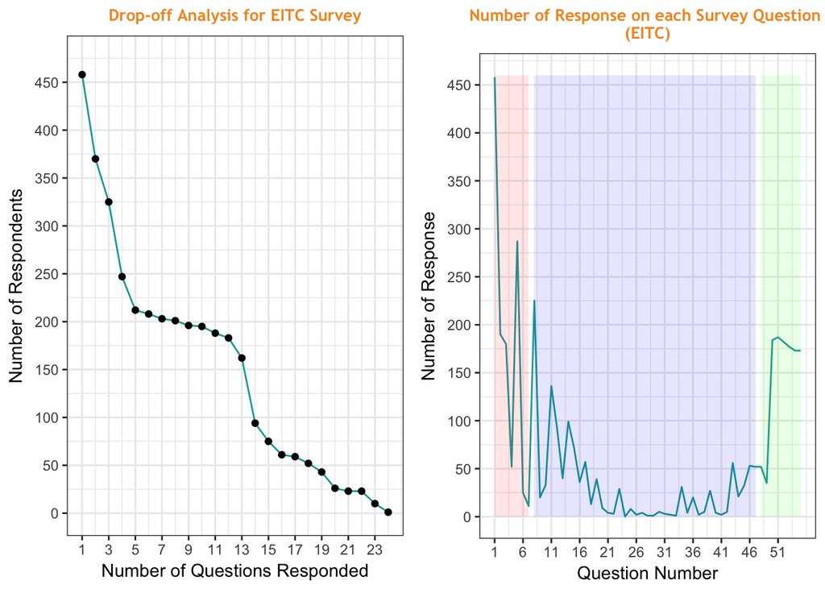

```r
#Arrange the two plots side by side.
grid.arrange(eitc_g1, eitc_g2, ncol = 2)
```

There are 458 respondents in this survey. From both graphs, we noticed immediately that the number of responses starts to decline near the very begining of the survey, and this is because this survey consists of two sub-parts, namely Broadband and EITC. In the graph on the right, the first seven quesitons (shaded in red) correspond to Broadband, and questions #8 to #46 (shaded in blue) correspond to the EITC. It appears that about half of the respondents did not take the EITC part after they completed Boardband. Questions #47 to #55 (shaded in green) are common quesitons asked in both Broadband and the EITC. Also, it seems like many of the EITC questions may not really apply to these respondents: the blue region has low response rate but the green region has almost the same number of responses as that of question #8 (the first question of EITC survey).

## Completion rate of Survey

In addition to the line graphs, we also quantified the completion rate of each question in these surveys and summarized them in the table below (we excluded the EITC survey since it infact consists of two surveys, which is atypical). The first column of the table is the number of questions completed by respondents, and the next six columns are proportions of respondents who completed that many of questions in each survey, or namely the completion rate of each question. For example, the fifth row of the second column (SJDD_Rate_1) shows the proportion of respondents who completed five questions in the SJDD survey(In-person and has internet), which is 0.9834711. The last two columns are the mean completion rate and standard deviation of each question.

```r
# Join dataframes.
all_RRate <- full_join(sjdd_RRate_1, sjdd_RRate_2, by = "q") %>%
  full_join(., sjdd_RRate_3, by = "q") %>%
  full_join(., sjdd_RRate_4, by = "q") %>%
  full_join(., sirum_RRate, by = "q") %>%
  full_join(., ecn_RRate, by = "q")

# Convert to datatable.
all_RRate <- as.data.table(all_RRate)

# Define a variable to store column names to be removed.
cols.chosen = c("numResponses.x", "numResponses.y", "numResponses.x.x", "numResponses.y.y",
                "numResponses.x.x.x", "numResponses.y.y.y")

# Remove all columns defined in cols.chosen.
Final_all_RRate <- all_RRate[, (cols.chosen) := NULL]

# Rename columns.
setnames(Final_all_RRate, c("SJDD_Rate.x","SJDD_Rate.y","SJDD_Rate.x.x","SJDD_Rate.y.y" ),
         c("SJDD_Rate_1","SJDD_Rate_2","SJDD_Rate_3","SJDD_Rate_4"))

setnames(Final_all_RRate, "q", "Num_of_Ques")

# Compute average completion rate of each question.
Final_all_RRate$Mean_Rate <- rowMeans(Final_all_RRate[,-1], na.rm = TRUE)
Final_all_RRate <- transform(Final_all_RRate,
                             SD_Rate=apply(Final_all_RRate[,-1],1, sd, na.rm = TRUE))
# Display table.
kable(Final_all_RRate)
```

| Num_of_Ques | SJDD_Rate_1 | SJDD_Rate_2 | SJDD_Rate_3 | SJDD_Rate_4 | Sirum_Rate | ECN_Rate | Mean_Rate | SD_Rate |
| --- | --- | --- | --- | --- | --- | --- | --- | --- |
| 1 | 1.0000000 | 1.0000000 | 1.0000000 | 1 | 1.0000000 | 1.0000000 | 1.0000000 | 0.0000000 |
| 2 | 1.0000000 | 1.0000000 | 1.0000000 | 1 | 1.0000000 | 1.0000000 | 1.0000000 | 0.0000000 |
| 3 | 1.0000000 | 1.0000000 | 1.0000000 | 1 | 1.0000000 | 1.0000000 | 1.0000000 | 0.0000000 |
| 4 | 0.9917355 | 0.9919355 | 1.0000000 | 1 | 1.0000000 | 1.0000000 | 0.9972785 | 0.0038492 |
| 5 | 0.9834711 | 0.9838710 | 0.9962406 | 1 | 1.0000000 | 1.0000000 | 0.9939304 | 0.0073762 |
| 6 | 0.9834711 | 0.9758065 | 0.9962406 | 1 | 1.0000000 | 1.0000000 | 0.9925864 | 0.0095122 |
| 7 | 0.9834711 | 0.9758065 | 0.9962406 | 1 | 1.0000000 | 1.0000000 | 0.9925864 | 0.0095122 |
| 8 | 0.9793388 | 0.9758065 | 0.9962406 | 1 | 0.9949749 | 1.0000000 | 0.9910601 | 0.0097645 |
| 9 | 0.9772727 | 0.9677419 | 0.9962406 | 1 | 0.9949749 | 1.0000000 | 0.9893717 | 0.0123742 |
| 10 | 0.9772727 | 0.9677419 | 0.9962406 | 1 | 0.9949749 | 1.0000000 | 0.9893717 | 0.0123742 |
| 11 | 0.9752066 | 0.9677419 | 0.9962406 | 1 | 0.9949749 | 1.0000000 | 0.9890273 | 0.0127298 |
| 12 | 0.9752066 | 0.9677419 | 0.9962406 | 1 | 0.9949749 | 1.0000000 | 0.9890273 | 0.0127298 |
| 13 | 0.9731405 | 0.9677419 | 0.9962406 | 1 | 0.9849246 | 1.0000000 | 0.9870079 | 0.0128495 |
| 14 | 0.9710744 | 0.9677419 | 0.9962406 | 1 | 0.9195980 | 1.0000000 | 0.9757758 | 0.0283873 |
| 15 | 0.9710744 | 0.9677419 | 0.9962406 | 1 | 0.6733668 | 1.0000000 | 0.9347373 | 0.1176331 |
| 16 | 0.9710744 | 0.9677419 | 0.9924812 | 1 | 0.6130653 | 1.0000000 | 0.9240605 | 0.1396731 |
| 17 | 0.9648760 | 0.9677419 | 0.9924812 | 1 | 0.1859296 | 0.9974359 | 0.8514108 | 0.2979305 |
| 18 | 0.9648760 | 0.9677419 | 0.9924812 | 1 | 0.1407035 | 0.9974359 | 0.8438731 | 0.3147682 |
| 19 | 0.9648760 | 0.9677419 | 0.9924812 | 1 | 0.0753769 | 0.9974359 | 0.8329853 | 0.3390924 |
| 20 | 0.9628099 | 0.9677419 | 0.9812030 | 1 | 0.0753769 | 0.9974359 | 0.8307613 | 0.3380979 |
| 21 | 0.9607438 | 0.9677419 | 0.9736842 | 1 | 0.0753769 | 0.9974359 | 0.8291638 | 0.3374163 |
| 22 | 0.7871901 | 0.9596774 | 0.9060150 | 1 | 0.0753769 | 0.9974359 | 0.7876159 | 0.3266087 |
| 23 | 0.7871901 | 0.9596774 | 0.9022556 | 1 | 0.0753769 | 0.9974359 | 0.7869893 | 0.3263845 |
| 24 | 0.7851240 | 0.9596774 | 0.8984962 | 1 | 0.0753769 | 0.9974359 | 0.7860184 | 0.3261662 |
| 25 | NA | 0.9596774 | NA | 1 | 0.0753769 | 0.9974359 | 0.7581226 | 0.3945065 |
| 26 | NA | 0.9596774 | NA | 1 | 0.0753769 | 0.9923077 | 0.7568405 | 0.3937343 |
| 27 | NA | 0.9516129 | NA | 1 | 0.0753769 | 0.8564103 | 0.7208500 | 0.3762274 |
| 28 | NA | NA | NA | NA | 0.0653266 | 0.8538462 | 0.4595864 | 0.3942598 |
| 29 | NA | NA | NA | NA | 0.0603015 | 0.4205128 | 0.2404072 | 0.1801057 |
| 30 | NA | NA | NA | NA | 0.0603015 | 0.4102564 | 0.2352790 | 0.1749775 |
| 31 | NA | NA | NA | NA | 0.0402010 | 0.2256410 | 0.1329210 | 0.0927200 |
| 32 | NA | NA | NA | NA | 0.0402010 | 0.2256410 | 0.1329210 | 0.0927200 |
| 33 | NA | NA | NA | NA | 0.0251256 | NA | 0.0251256 | 0.0000000 |
| 34 | NA | NA | NA | NA | 0.0251256 | NA | 0.0251256 | 0.0000000 |
| 35 | NA | NA | NA | NA | 0.0150754 | NA | 0.0150754 | 0.0000000 |
| 36 | NA | NA | NA | NA | 0.0100503 | NA | 0.0100503 | 0.0000000 |

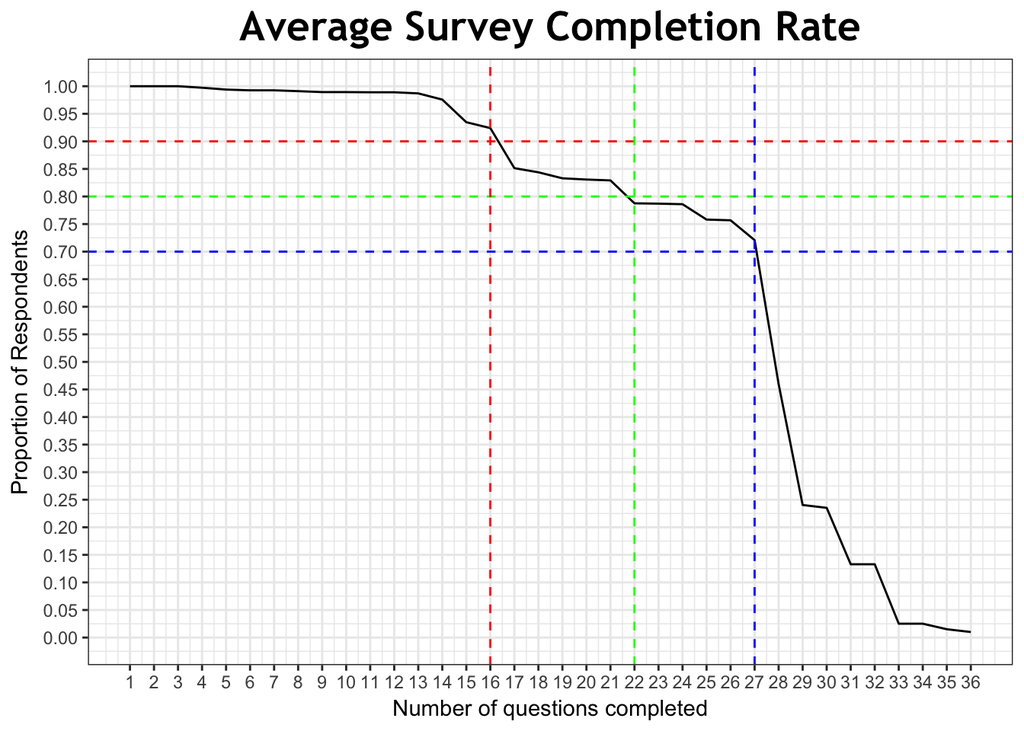

```r
# Plot the average survey completion rate.
ggplot(data = Final_all_RRate, aes(x = Num_of_Ques, y = Mean_Rate)) +
  geom_line(color = "black") +
  theme_bw()+
  scale_x_continuous(breaks = seq(1,36,by = 1), limits = c(1,36)) +
  scale_y_continuous(breaks = seq(0,1,by = 0.05), limits = c(0,1)) +
  ggtitle(("Average Survey Completion Rate")) +
  xlab("Number of questions completed") +
  ylab("Proportion of Respondents") +
  theme(plot.title = element_text(family = "Trebuchet MS",
                                  color = "black",
                                  face = "bold",
                                  size = 20,
                                  hjust = 0.5)) +
    geom_hline(yintercept=0.9, color='red', linetype='dashed') +
    geom_hline(yintercept=0.8, color='green', linetype='dashed') +
    geom_hline(yintercept=0.7, color='blue', linetype='dashed') +
    geom_vline(xintercept=16, color='red', linetype='dashed') +
    geom_vline(xintercept=22, color='green', linetype='dashed') +
    geom_vline(xintercept=27, color='blue', linetype='dashed')
```

Next, we want to quantify a range for survey length for the three levels of completion rate(90%, 80%, and 70%). To do this, we take the last value in the “Num_of_Ques” column of the Completion rate table that has a completion rate euqual to or above the desired completion rate. For example, in order to find the maximum number of questions completed by at least 90% of respondents in a survey, we search for the last value we see in each column that is equal to or greater than 0.9, and the corresponding value in the “Num_of_Ques” column is the maximun survey length in that survey for a 90%+ completion rate, which in this case are 21, 27, 23, 27, 14, and 26. We then go through the same steps for the 80% and 70% completion rate. Then, we take the average and standard deviation of these numbers to calculate a 95% confidence interval for each completion rate level as shown below:

```r
# Compute 95% Confidence Interval for the max.length of question for 90% completion rate.

n = 6                              # Number of surveys
pct90 <- c(21, 27, 23, 27, 14, 26) # Number of questions completed by 90% of respondents per survey
xbar = mean(pct90)                 # Sample mean
s = sd(pct90)                      # Sample standard deviation
SE = s/sqrt(n)                     # Standard error estimate
E = qt(.975, df=n-1)*SE            # Margin of error
CI90 = xbar + c(-E, E)             # 95% Confidence Interval
CI90
```

```
## [1] 17.73187 28.26813
```

```r
# Compute 95% Confidence Interval for the max.length of question for 80% completion rate.
n = 6
pct80 <- c(21, 27, 24, 27, 14, 28)
xbar = mean(pct80)
s = sd(pct80)
SE = s/sqrt(n)
E = qt(.975, df=n-1)*SE
CI80 = xbar + c(-E, E)
CI80
```

```
## [1] 17.91724 29.08276
```

```r
# Compute 95% Confidence Interval for the max.length of question for 80% completion rate.
n = 6
pct70 <- c(24, 27, 24, 28, 14, 28)
xbar = mean(pct70)
s = sd(pct70)
SE = s/sqrt(n)
E = qt(.975, df=n-1)*SE
CI70 = xbar + c(-E, E)
CI70
```

```
## [1] 18.59707 29.73626
```

Based on the 95% confidence intervals we generated above, in order to have at least a 90% completion rate, the maximun length of questions we should include in our future surveys is between 17 and 28. Similarly, for at least a 80% completion rate, the survey length should between 17 and 29; for at least a 70% completion rate, the maximum number of questions we could ask is between 18 and 29. Notice that the maximun survey lengths for the 80% and 70% completion rate suggested by the “Average Survey Completion Rate” figure (22 and 27 respectively) are also within the range of their confidence interval; and although the maximun length for the 90% completion rate (16) is not in the range of its confidence interval, it is very close to be included in the range.

## Conclusion

Based on the visualized data and the confidence intervals, the survey completion rate seems to be affected by the length of our surveys; however, the decrease in completion rate is very likely resulted from either questions that are not applicable to the respondents or questions that split the flow into multiple paths. At this point, we are 95% confident to say that we can include 17 to 28 questions in our future surveys and still have 90% of completion rate.

Our data for EITC also suggest that we should not include sub-surveys in a survey in the future as it may result in a low completion rate; however, this may not be absolutely true since we only have one such survey to do analysis on.